# Deuxième analyse

PERRAUD Louis

06/05/2022

# 1 Superposition vote et carroyage

Hypothèse : les individus vivant seuls ont une propension à voter pour V.DUGUET.

## 1.1 Préparation de la donnée

```r
library(sf)
library(mapsf)
Insee_bondy <- st_read("../data/insee.gpkg","bondy")
Votes<- st_read("../data/vote.gpkg", "jointure")
names(Votes)
```

```
##  [1] "cle"
##  [2] "Layer"
##  [3] "bureauNo_1"
##  [4] "aire"
##  [5] "numBureau"
##  [6] "txVotants"
##  [7] "Bureau.de.vote"
##  [8] "Nb.d.électeurs.inscrits"
##  [9] "Nb.de.votants"
## [10] "Taux.de.participation...."
## [11] "Nb.votes.nuls"
## [12] "Nb.votes.blancs"
## [13] "Suffrages.exprimés"
## [14] "Résultats.liste.1...Liste.de.la.gauche.unie.pour.Bondy....Sylvine.THOMASSIN."
## [15] "Résultats.liste.2....Pour.Bondy.allons.plus.loin....Stephen.HERVE"
## [16] "Résultats.liste.3....Bondy.pour.une.gauche.sociale.insoumise.et.populaire....Jamal.AMMOURI"
## [17] "Résultats.liste.4....Bondy.autrement...Vincent.DUGUET"
## [18] "Résultats.liste.5....Bondy.c.est.vous...Sylvie.BADOUX"
## [19] "geom"
```

```r
Votes[3]
```

```
## Simple feature collection with 30 features and 1 field
## Geometry type: MULTIPOLYGON
## Dimension:     XY
## Bounding box:  xmin: 661088.1 ymin: 6865338 xmax: 663354.7 ymax: 6869043
## Projected CRS: RGF93 / Lambert-93
## First 10 features:
##                             bureauNo_1                           geom
## 1     HOTEL DE VILLE - SALLE DES FETES MULTIPOLYGON (((661895.1 68...
## 2             ECOLE MATERNELLE MAINGUY MULTIPOLYGON (((661681.9 68...
## 3         GYMNASE AIACHE - SALLE DANSE MULTIPOLYGON (((661336.9 68...
## 4            ECOLE MATERNELLE JEAN ZAY MULTIPOLYGON (((661220.1 68...
## 5        ECOLE MATERNELLE NOUE CAILLET MULTIPOLYGON (((661873.5 68...
## 6  ECOLE MATERNELLE TERRE SAINT BLAISE MULTIPOLYGON (((661846.8 68...
## 7             ECOLE MATERNELLE PASTEUR MULTIPOLYGON (((662412.1 68...
## 8       ECOLE MATERNELLE HENRI SELLIER MULTIPOLYGON (((662661 6866...
## 9     ECOLE MATERNELLE CAMILLE CLAUDEL MULTIPOLYGON (((662268.3 68...
## 10       ECOLE ELEMENTAIRE JULES FERRY MULTIPOLYGON (((662317.5 68...
```

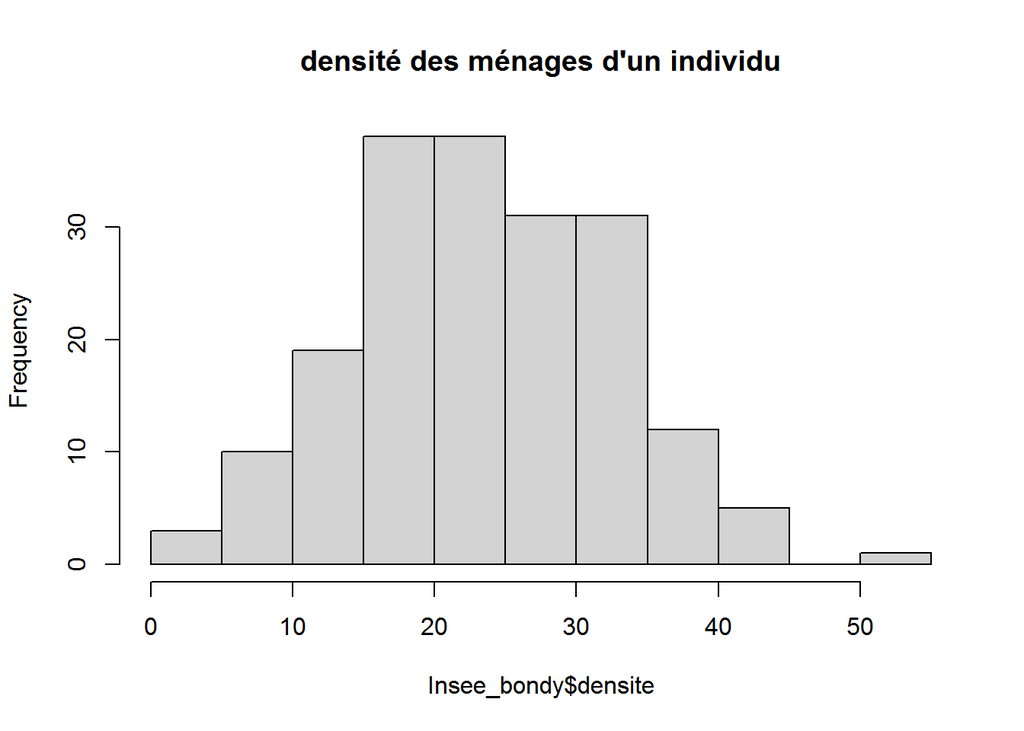

```r
names(Votes)[c(3,17)] <- c("bureau", "vote")
Votes <- Votes [, c("bureau", "vote")]
# Pour obtenir un chiffre relatif, on divise le nombre de ménages d'un individu par le nombre de ménages total
Insee_bondy$densite <- (Insee_bondy$Men_1ind / Insee_bondy$Men)*100
Insee_bondy <- Insee_bondy [, "densite"]
hist(Insee_bondy$densite, main = "densité des ménages d'un individu")
```

En général à Bondy, il y a entre 15 et 25% de ménage d’un individu. On remarque une valeur exceptionnelle de plus de 50%, sûrement au centre.

## 1.2 Traitement de la donnée

### 1.2.1 Intersection

Afin de pouvoir croiser grille et polygone, il faut d’abord intersecter les deux de façon à récupérer le nom du bureau de vote pour chaque carreau de la grille.

```r
inter <- st_intersection(Votes, Insee_bondy)
summary(inter)
```

```
##     bureau               vote          densite                      geom
##  Length:333         Min.   : 1.00   Min.   : 0.00   GEOMETRYCOLLECTION:  2
##  Class :character   1st Qu.:10.00   1st Qu.:17.58   MULTIPOLYGON      : 22
##  Mode  :character   Median :14.00   Median :22.77   POLYGON           :309
##                     Mean   :14.57   Mean   :23.88   epsg:2154         :  0
##                     3rd Qu.:18.00   3rd Qu.:31.03   +proj=lcc ...     :  0
##                     Max.   :35.00   Max.   :52.97
```

```r
# la cartographie des multipolygones ne fonctionne pas, on passe tout en polygone
inter <- st_cast(inter, "POLYGON")
```

### 1.2.2 Une première cartographie

```r
mf_export(inter, filename ="../img/propchoroF.png", width = 1000, res = 200, expandBB = c(0,0,0,0.6))
mf_map(inter, col = "orange", border = "antiquewhite1")
mf_map(inter, type ="prop_choro", var = c("vote", "densite"), leg_pos = c("topright", "right"))
mf_layout("Illisible", credits = "INSEE / PV Electoral\nBondy, avril 2022")
dev.off()
```

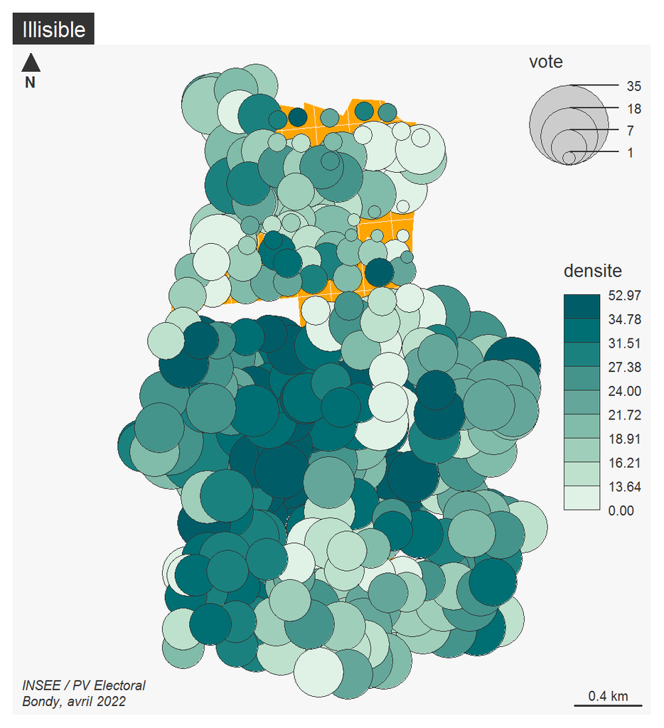

La carte est illisible.

## 1.3 Agrégation

Pour chaque bureau de vote, il faut calculer la somme de la densité des ménages d’un individu.

On intersecte insee et bureaux, puis on calcule la densité ménages par rapport à la taille du carreau, puis on fait la somme de tous les carrés dans un bureau.

Les carreaux du carroyage devraient faire 40000 m2 chacun. Or ce n’est pas le cas :

```r
st_area(inter)
```

```
## Units: [m^2]
##   [1] 2.122679e+01 2.024926e+03 4.754607e+03 3.999163e+04 3.999358e+04
##   [6] 1.954717e+04 1.823731e+03 2.202121e+04 2.478145e+03 3.518522e+04
##  [11] 3.325654e+02 9.002025e+03 2.899305e+04 5.180168e+01 7.384069e+03
##  [16] 1.893581e+04 1.005916e+04 3.860953e+04 5.587639e+02 8.904872e+03
##  [21] 1.000509e+04 3.736588e+04 1.396785e+01 3.035877e+02 2.765974e+04
##  [26] 1.500683e+04 1.151303e+03 2.552953e+04 4.239836e+02 3.882864e+04
##  [31] 2.534872e+04 2.472424e+04 7.407254e+03 1.111369e+04 3.952189e+04
##  [36] 1.300702e+02 2.137273e+04 1.274985e+02 2.785676e+03 3.601823e+04
##  [41] 2.858931e+04 2.340401e+02 6.901937e+03 2.397689e+04 1.106208e+02
##  [46] 9.644265e+02 3.467207e+04 2.703120e+04 6.797458e+03 2.381519e+04
##  [51] 9.455134e+03 1.869925e+04 1.713383e+04 2.286393e+04 7.395764e+03
##  [56] 4.158838e+01 3.872581e+04 1.500348e+04 8.998292e+02 2.520693e+04
##  [61] 1.315115e+04 1.420903e+04 1.095875e+04 2.702555e+04 4.322359e+03
##  [66] 3.259036e+04 1.143977e+02 2.495693e+04 9.800867e+02 1.127399e+04
```

[output cut: 53 more lines]

```r
st_area(Insee_bondy)
```

```
## Units: [m^2]
##   [1] 39993.79926 39993.73430 39993.77762 39993.31220 39993.57714 39993.76679
##   [7] 39993.72346 39993.50144 39993.71262   702.54682 12056.79672 39993.51227
##  [13] 39993.75597 34169.99624 39993.30140 39993.56634 39993.78844  5083.83817
##  [19] 27268.59590 39993.49062  3832.67427 38959.89885 39993.52309 36881.84685
##  [25] 39994.17944 39993.55553 17771.09547 39993.54472 39993.70178 39993.74513
##  [31] 38901.30937   291.78990 39994.31813 32244.66327  8781.11552 30401.68589
##  [37] 39691.13394 36321.93056 39993.53390 39994.73244 39993.88338 22110.07716
##  [43] 39994.72153 25769.10739   348.00238 39994.30726 39994.20117  3917.72357
##  [49] 39994.29639 39994.22288 39993.33380 39993.34459 39994.28552 39993.86171
##  [55] 39994.16858 39994.15771 39994.71063  9239.01822 32399.13802 39921.47984
##  [61] 14807.27767 39993.87255 39994.14683 39993.32300 39994.69971 39995.01938
##  [67] 39994.99749  7196.07610 39994.19031 39995.00844 11541.81416 39994.46522
##  [73] 39993.89422    17.00711 39994.68880 39993.85087 39993.82918 39994.91274
##  [79] 39994.21203   153.96641 39994.89087 39994.59332 39993.80748 38206.97559
```

[output cut: 18 more lines]

Ces variation sont dues aux différentes intersection entre carreaux et bureaux. Pour obtenir une juste densité, il faut tout de même tenir compte de la superficie.

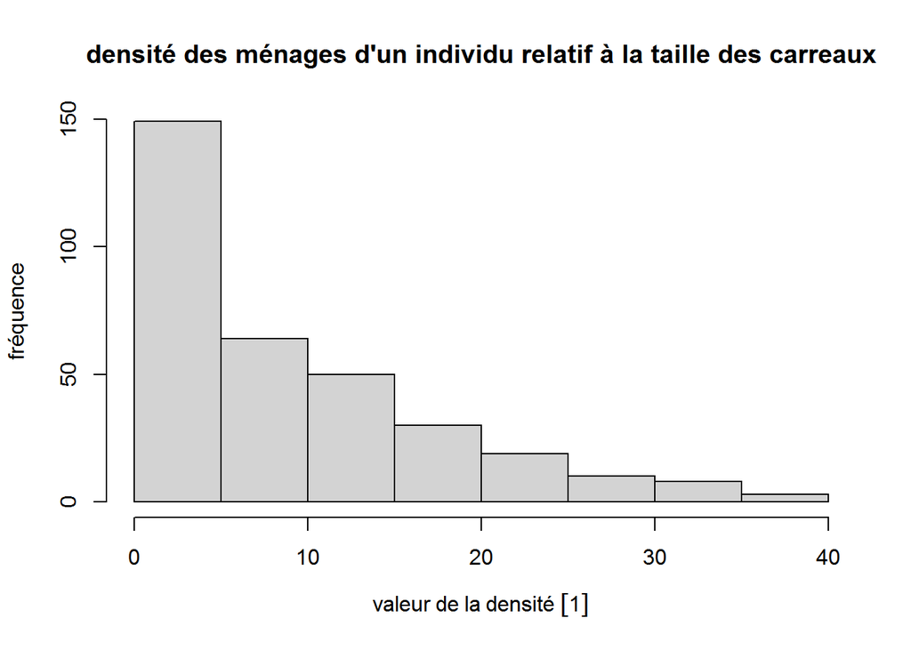

```r
# Il ne faut pas oublier les carreaux frontières...
# certains carreaux sont coupés par les limites des bureaux. la densité des ménages doit être rapportée à l'aire de la géométrie.
#On crée un champ pour l'aire totale :
Insee_bondy$aireTot <- st_area(Insee_bondy)
inter <- st_intersection(Votes, Insee_bondy)
# On fait le rapport : proportion de ménages pauvres x aire du carreau intersécté/aire totale du carreau.
inter$nbRel <- (inter$densite * (st_area(inter)/ inter$aireTot) )
hist(inter$nbRel, main = "densité des ménages d'un individu relatif à la taille des carreaux", xlab = "valeur de la densité", ylab = "fréquence")
```

Ici, en utilisant la taille des parties de carreaux, on obtient beaucoup de zones avec une densité faible et quelques unes avec une grosse densité.

```r
# Enfin, on agrége les carreaux aux bureaux
agg <- aggregate (inter$nbRel , by = list(inter$bureau), sum )
agg
```

```
##                                          Group.1             x
## 1              CENTRE DE LOISIRS - SALLE COLUCHE 109.98873 [1]
## 2                  CENTRE DE LOISIRS APPOLINAIRE  56.79078 [1]
## 3  CENTRE DE LOISIRS COLUCHE - SALLE POLYVALENTE 106.84643 [1]
## 4                 CENTRE DE LOISIRS PIERRE CURIE 123.34070 [1]
## 5              ECOLE ELEMENTAIRE ANDRE BOULLOCHE  92.35812 [1]
## 6                  ECOLE ELEMENTAIRE JULES FERRY  79.28540 [1]
## 7                 ECOLE ELEMENTAIRE LEO LAGRANGE 143.81296 [1]
## 8             ECOLE ELEMENTAIRE MAINGUY-GUEHENNO  44.68887 [1]
## 9                 ECOLE ELEMENTAIRE NOUE CAILLET  79.53616 [1]
## 10            ECOLE ELEMENTAIRE OLYMPE DE GOUGES  84.77897 [1]
## 11                     ECOLE ELEMENTAIRE PASTEUR  48.24823 [1]
## 12                    ECOLE ELEMENTAIRE SALENGRO 197.40908 [1]
## 13              ECOLE MATERNELLE CAMILLE CLAUDEL  56.33524 [1]
## 14                ECOLE MATERNELLE HENRI SELLIER 111.55126 [1]
```

[output cut: 16 more lines]

```r
# On renomme pour faire la jointure.
names(agg) <- c("bureau", "densite")
# jointure
names(Votes)
```

```
## [1] "bureau" "vote"   "geom"
```

```r
jointure <- merge(Votes, agg, by = "bureau")
names(jointure)
```

```
## [1] "bureau"   "vote"     "densite"  "geometry"
```

```r
jointure$densite <- round(jointure$densite,0)
jointure$densite
```

```
## Units: [1]
##  [1] 110  57 107 123  92  79 144  45  80  85  48 197  56 112 113  54 119 124  27
## [20] 150  78  84 136  79 137  85 116  97  35 141
```

```r
# Problème sur les unités en mètres carrés, il faut s'en débarasser.
library(units)
jointure$densite <- drop_units(jointure$densite)
```

```r
mf_export(inter, filename ="../img/superp.png", width = 1000, res = 200, expandBB = c(0,0,0,0.8))
mf_map(jointure, col = "antiquewhite1", border = "grey")
mf_map(jointure, type ="prop_choro", var = c("vote", "densite"), border = NA, leg_pos = c("topright", "right"), leg_title = c("vote (nb)", "densité\nMenInd (%)"))
mf_layout(title = "Les ménages d'un individu votent V.DUGUET", credits = "INSEE / PV électoral\nBondy, avril 2022")
dev.off()
```

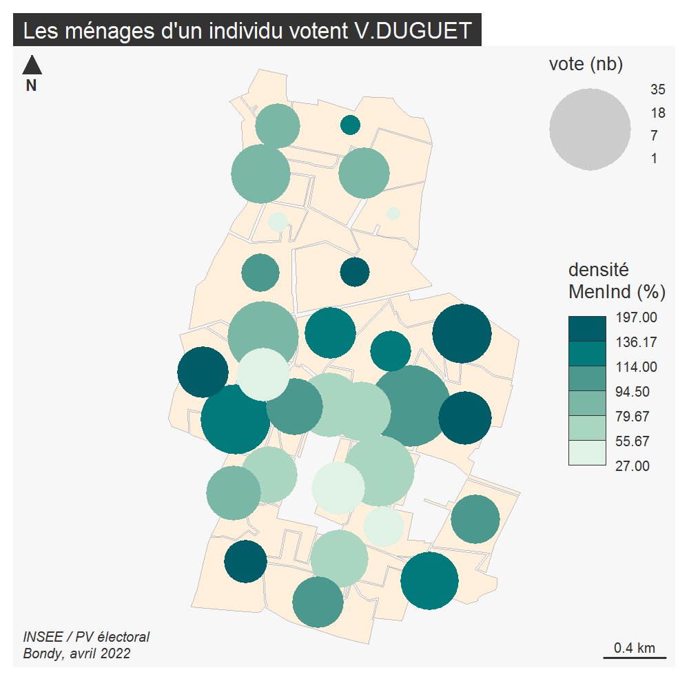

En réalité la carte conteste cette conclusion : les cercles les plus foncés ne sont pas les plus grands, la relation entre votes de V.DUGUET et densité des menages individuels n’est pas avérée.